# National Snapshot

210,000

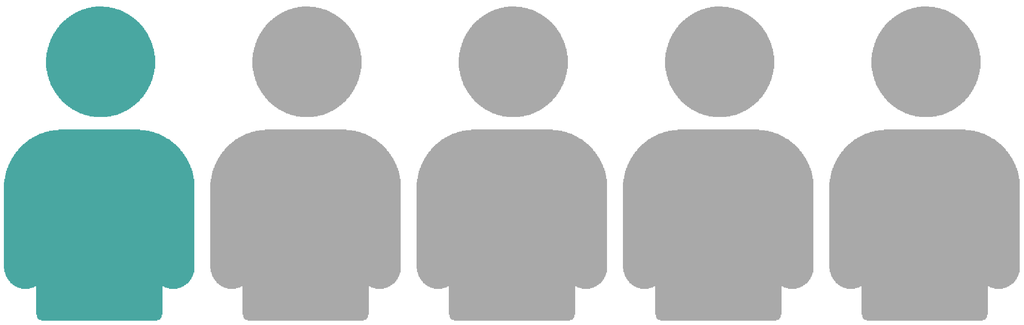

34

People In Prison Past Parole Eligibility*

1 in 5 People Are Incarcerated Past Parole Eligibility**

States With Discretionary Parole**

*These 2023 projections are conservative estimates based on data submitted from 31 of the 34 states with discretionary parole through the National Corrections Reporting Program (NCRP) and original data requests. When parole eligibility year (PEY) was not reported in NCRP, we used sentencing rules to estimate PEY, opting for the most conservative end of the range (e.g., if individuals are required to serve 25-75 percent of their maximum sentence, we used 75 percent as the PEY). Estimates could not fully account for “good time” credits or time that should be subtracted from a person’s sentence. As a result, the actual number of people held beyond their eligible parole dates is likely higher than our data suggests. Estimates exclude: (1) people incarcerated for parole violations or revocations, (2) people with life sentences, and (3) people with sentences less than one year.  
**Louisiana eliminated discretionary parole in 2024, but it is listed among the 34 paroling states as the majority of the population remains eligible for parole release under the previous system.

[interactive chart not shown]

Download Map

## Parole Eligibility by State

The table below provides estimates for the percentage and number of people in prison past their parole eligibility date in 31 of the 34 paroling states. It also highlights the number of parole board members for each state.

| State | Percentage of People in Prison | Number of People | Parole Board Members* |
| --- | --- | --- | --- |
| Alabama | 20 | 3000 | 3 |
| Arkansas | 7 | 780 | 7 |
| Colorado | 32 | 3600 | 9 |
| Connecticut | 37 | 2500 | 15 |
| Georgia | 68 | 25000 | 5 |
| Hawaii | 98 | 3400 | 5 |
| Idaho | 33 | 2500 | 7 |
| Iowa | 68 | 4300 | 5 |
| Kentucky | 50 | 7000 | 9 |
| Louisiana | 35 | 6600 | 7 |

[output cut: 21 more lines]

Source: National Corrections Reporting Program, 2010-2020 and CSG Justice Center estimates.  
*The number of parole board members includes appointed members and does not include subordinate hearing examiners that many states employ.